# Correlations between ADI-R Subscore A and Individual Specific DEGs

## **1. Introduction**

Velmeshev, Dmitry, et al. (2019)에서 ASD 환자들의 single-cell profiles와 대조군의 profiles를 비교한 결과 L2/3, L5/6-CC을 포함한 여러 cell type에서 환자들의 ADI-R scores와 상관관계를 보였다. 또한 ADI-R scores와 가장 상관관계가 높은 differentially expressed genes (DEGs)는 transcriptional dysregulation의 정도가 높은 DEGs과는 관련이 적었다. 따라서, 유전자 발현량의 Fold change(ASD versus control) 수치만을 보기보다는 환자들에게 공통으로 발현되는 DEGs를 고려하여 ADI-R score의 상관관계를 분석하고자 한다.

논문에서 Combined ADI-R score을 산출할 때 각 점수의 rank를 구하여 합친다라고 간략하게만 나와 있고 B subscore인 verbal과 nonverbal에 대한 처리가 나와 있지 않다. 그래서 이 Portfolio에서는 ADI-R score 중에서 variation이 score 중에서 가장 높은 A score(reciprocal social interaction의 이상 정도)와 cell type마다 갖고 있는 Individual specific DEGs의 수에 Fold change을 가중치로 부여한 값을 비교한다. 환자들의 ADI-R A score는 위 논문의 Data S1에서 확인할 수 있었고, Individual specific DEGs는 Data S4에서 5명 이상의 환자로부터 유의적으로 발현량 차이가 있는 유전자를 이용하였다.

## **2. Data Pre-processing**

우선, excel 파일을 불러오고 데이터를 처리할 수 있는 Package를 불러온다.

```r
# Load packages
library(tidyverse)
library(readxl)
```

이제 사용할 데이터를 읽어보자.

```r
# Read excel files
S1_1 <- read_excel("aav8130_Data_S1.xlsx", sheet = 1)
S4_1 <- read_excel("aav8130_Data_S4.xls", sheet = 1)
S4_4 <- read_excel("aav8130_Data_S4.xls", sheet = 4)
```

데이터가 잘 읽혔는지 확인해 본다.

```r
colnames(S1_1)
```

```
 [1] "Patient ID"      "Diagnosis"       "Age"
 [4] "Sex"             "PMI"             "Other diagnoses"
 [7] "Medications"     "ADI-R"           "...9"
[10] "...10"           "...11"           "...12"
[13] "Cause of death"
```

```r
colnames(S4_1)
```

```
 [1] "Cell type"
 [2] "gene ID"
 [3] "Gene name"
 [4] "Gene biotype"
 [5] "Fold change"
 [6] "Sample fold change"
 [7] "q value"
 [8] "correlation (bulk mRNA/bulkized nuclear RNA)"
 [9] "Epilepsy DEG"
[10] "gene group"
[11] "SFARI gene"
[12] "Satterstrom"
[13] "Sanders"
[14] "cell type-specific expression"
```

```r
colnames(S4_4)
```

```
[1] "Cell type"
[2] "Gene ID"
[3] "Gene name"
[4] "Direction of change (ASD/Control)"
[5] "# of ASD patients with significant change"
[6] "ASD patients with DE signal"
```

`S1_1`의 데이터를 살펴보면 `S1_1`의 열 이름 중에 ADI-R scores가 누락되어 1행이 존재하는 것을 알 수 있다. 따라서 1행을 삭제해 주고 열 이름을 다시 지정해주어야 한다.

```r
S1_1 <- S1_1[-1,]
colnames(S1_1)[8:12] <- c('A','Bv','Bnv','C','D')
```

대조군 집단과 일부 환자들의 `A` score가 결측치로 되어 있기 때문에 `filter` 함수를 통해 이를 제외한다. 또한 `Patient ID`는 범주형 변수로 활용하기 위해 character로, `A` score는 양적 변수로 활용하기 위해 numeric으로 class를 바꾸어 준다. 사용할 정보는 이 두 개의 정보 밖에 없으므로 `select` 함수로 간단하게 해준다.

```r
S1_1 <- S1_1 %>% filter(!(A=='NA')) %>%
  mutate('Patient ID' = as.character(`Patient ID`), A = as.numeric(A)) %>%
  select(`Patient ID`, A)
S1_1
```

| Patient ID | A |
| --- | --- |
| 5278 | 22 |
| 5144 | 28 |
| 5403 | 30 |
| 5419 | 24 |
| 4899 | 22 |
| 5978 | 13 |
| 6033 | 26 |
| 5864 | 18 |
| 5939 | 29 |
| 5565 | 27 |

[output cut: 2 more lines]

`S4_4`의 데이터의 경우 우리가 사용할 patient ID 정보가 `ASD patients with DE signal`에 한 문자열로 묶여 있다. 환자마다 각각의 유전자가 DEGs인지 확인하기 위해서 `str_count` 함수를 이용하여 `ASD patients with DE signal`에서 추출된 patient ID들 중에 알고 싶은 환자 ID가 포함되어 있는지 확인하면 된다. 해당 환자 ID가 포함되어 있다면 `1`이, 포함되어 있지 않다면 `0`이 결과값이 된다. A score를 갖고 있는 모든 환자에 대해서 조사하려면 `sapply` 함수를 사용한다. 이를 통해 생성된 data.frame을 `ind_DEGs`에 지정한다.

```r
ind_DEGs <- sapply(S1_1$`Patient ID`,
                     function(ID) str_count(S4_4$`ASD patients with DE signal`, ID))
head(ind_DEGs)
```

```
     5278 5144 5403 5419 4899 5978 6033 5864 5939 5565
[1,]    0    0    0    0    0    1    1    1    1    1
[2,]    0    0    1    0    0    0    1    0    0    1
[3,]    0    0    1    0    1    1    0    1    1    1
[4,]    0    0    0    0    0    0    1    1    0    1
[5,]    0    1    0    0    0    1    1    0    1    1
[6,]    0    1    0    0    0    0    0    1    1    1
     5294 4849
[1,]    0    1
[2,]    0    1
[3,]    0    1
[4,]    0    1
[5,]    0    1
[6,]    0    1
```

`cbind` 함수를 이용하여 `ind_DEGs`를 S4_4에 붙여보자.

```r
S4_4 <- cbind(S4_4, ind_DEGs)
```

이제 환자마다 cell type에 따른 indivisual specific DEGs의 수를 찾아본다. `group_by` 함수로 `Cell type`에 따라 grouping하고 각 환자에 대해서 `ind_DEGs` 행들의 합을 구한다. 이 때 단지 DEGs의 수만으로 A score와의 관계를 설명하는 것은 무리가 있다. 따라서 gene마다 얼마나 영향을 주는지를 고려하여 각 `Cell type`의 genes의 Fold Change의 절대값을 가중치로 두고 합한다. `summarize_at` 함수를 통해 이 값을 한꺼번에 구할 수 있다. 이 결과를 `effect`에 지정한다.

```r
effect <- S4_4 %>% merge(S4_1 %>% select(`Cell type`, `Gene name`, `Fold change`)) %>% mutate("Fold change" = abs(`Fold change`)) %>% mutate_at(vars(`5278`:`4849`), function(x) x*.$`Fold change`) %>% group_by(`Cell type`) %>% summarise_at(vars(`5278`:`4849`), sum)
effect
```

| Cell type | 5278 | 5144 | 5403 | 5419 | 4899 | 5978 | 6033 | 5864 | 5939 | 5565 | 5294 | 4849 |
| --- | --- | --- | --- | --- | --- | --- | --- | --- | --- | --- | --- | --- |
| AST-FB | 0.000 | 0.000 | 0.000 | 0.000 | 0.000 | 0.000 | 0.000 | 0.463 | 0.000 | 0.000 | 0.463 | 0.000 |
| AST-PP | 0.804 | 0.791 | 2.175 | 0.462 | 0.452 | 3.835 | 1.958 | 2.736 | 1.901 | 2.816 | 0.323 | 2.191 |
| IN-PV | 0.000 | 0.000 | 0.289 | 0.000 | 0.183 | 0.748 | 0.728 | 0.684 | 1.172 | 1.461 | 0.000 | 0.289 |
| IN-SST | 0.150 | 0.705 | 0.288 | 0.150 | 0.000 | 1.233 | 0.945 | 0.288 | 1.233 | 1.233 | 0.000 | 0.000 |
| IN-SV2C | 0.000 | 0.000 | 0.000 | 0.000 | 0.000 | 0.000 | 0.000 | 0.357 | 0.357 | 0.357 | 0.357 | 0.000 |
| IN-VIP | 1.576 | 2.381 | 1.083 | 1.934 | 0.237 | 5.849 | 1.875 | 1.972 | 5.639 | 5.385 | 0.690 | 1.894 |
| L2/3 | 1.969 | 3.777 | 3.761 | 2.769 | 4.351 | 5.706 | 6.186 | 4.383 | 6.287 | 6.495 | 0.941 | 4.200 |
| L4 | 2.024 | 4.212 | 6.524 | 3.721 | 3.107 | 5.637 | 4.372 | 3.568 | 7.148 | 6.501 | 1.665 | 2.567 |
| L5/6 | 0.000 | 0.000 | 0.000 | 0.000 | 0.000 | 0.552 | 0.552 | 0.552 | 0.344 | 0.552 | 0.000 | 0.209 |
| L5/6-CC | 0.468 | 0.269 | 0.862 | 0.000 | 1.404 | 1.569 | 2.072 | 0.827 | 1.674 | 1.619 | 0.709 | 0.951 |

[output cut: 3 more lines]

환자 `A` score와 `effect`를 비교하기 위해서 우선 `gather` 함수를 이용하여 `effect`를 *long format*으로 바꿔준다. 그리고 `A` score 정보를 가진 `S1_1`를 `merge` 함수를 통해 합쳐준다. 이 data.frame을 편의를 위해 `df`라고 지정한다.

```r
# transform data.frame from wide into long format
df <- effect %>% gather(`Patient ID`, effect, -`Cell type`) %>% merge(S1_1)
```

## **3. Data Visualization**

분석을 하기 전에 우선 데이터가 어떻게 분포되어 있는지 확인해 보자.

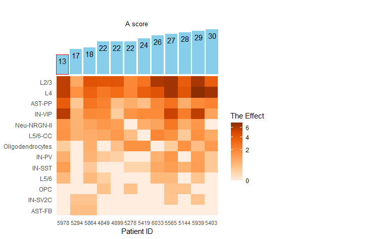

```r
library(RColorBrewer)
library(cowplot)
tile <- df %>% ggplot(aes(reorder(`Patient ID`, A, median),
                          reorder(`Cell type`, effect, median), fill = effect)) +
  geom_tile() +
  labs(x = "Patient ID", y = NULL, fill = "The Effect") +
  scale_fill_distiller(trans = "sqrt", type = "seq", palette = 7, direction = 1) +
  theme_minimal() +
  theme(panel.grid = element_blank(),axis.text.x = element_text(size = 8))
xplot <- df %>% group_by(`Patient ID`) %>%
  summarise(A = mean(A)) %>%
  ggplot(aes(reorder(`Patient ID`, A), A, label = A)) +
  geom_bar(stat = "identity", fill = "skyblue", show.legend = F,
           color = ifelse(df %>% group_by(`Patient ID`) %>%
                            summarise(A = mean(A)) %>% .$A == 13, "red", NA)) +
  geom_text(vjust = 1.5, size = 4, show.legend = F) +
  ggtitle("A score") + theme_void() +
  theme(plot.title = element_text(size = 10, hjust = 0.5))
ggdraw() +
  draw_plot(xplot, .14, .68, width = .428, height = .25) +
  draw_plot(tile, 0, 0 , width = .7, height = .7)
```

`ggplot`를 이용하여 `Cell type`에 따른 A score와 DEGs의 `effect` 값을 비교했을 때, `Cell type`마다 DEGs의 차이가 크고 `effect` 값에 0이 많은 `Cell type`이 많아서 상관분석에 불리하다. 또한 빨간 막대로 표시된 환자는 나머지 환자들과 `effect`에서 완전히 다른 양상을 보였다. `Cell type`별로 *Pearson correlation analysis*를 구해보면 다음과 같다.

```r
df %>% group_by(`Cell type`) %>%
  summarize(r = cor(A, effect, method = "pearson"),
            p.value = cor.test(A, effect, method = "pearson")$p.value) %>%
  arrange(p.value)
```

| Cell type | r | p.value |
| --- | --- | --- |
| AST-FB | -0.5071 | 0.0924 |
| L4 | 0.4937 | 0.1029 |
| Oligodendrocytes | 0.3529 | 0.2605 |
| L2/3 | 0.2642 | 0.4066 |
| OPC | 0.2240 | 0.4839 |
| L5/6 | -0.2023 | 0.5283 |
| IN-SST | 0.1990 | 0.5353 |
| AST-PP | -0.1945 | 0.5447 |
| IN-PV | 0.1682 | 0.6013 |
| IN-SV2C | -0.0590 | 0.8556 |

[output cut: 3 more lines]

상관계수가 $p<.05$을 만족시키는 `Cell type`은 존재하지 않았다. 그 이유로 연구에 사용된 ASD 환자 샘플 수가 적어서 빨간 막대로 표시된 다른 양상을 보이는 환자에 의해 분석의 신뢰도가 낮아진 것으로 보인다. 따라서 이 환자를 제외하여 분석을 해봤다. 또한 `effect`의 0 값이 대부분인 `Cell type`의 경우 잘못된 상관관계가 나타날 수 있어서 이 세포들을 제외하고 다시 분석을 진행해보았다.

| Cell type | r | p.value |
| --- | --- | --- |
| L4 | 0.8331 | 0.00145 |
| IN-SST | 0.6558 | 0.02846 |
| L2/3 | 0.5593 | 0.07364 |
| IN-VIP | 0.5043 | 0.11370 |
| IN-PV | 0.3600 | 0.27677 |
| Oligodendrocytes | 0.2881 | 0.39023 |
| AST-PP | 0.2668 | 0.42777 |
| L5/6-CC | 0.2551 | 0.44899 |
| Neu-NRGN-II | 0.0902 | 0.79192 |
| L5/6 | 0.0503 | 0.88318 |

분석 결과 $p<.05$을 만족하는 `Cell type`은 `L4`, `IN-SST`이었다. 상관관계 분석 결과와 $p<.05$를 만족하는 `Cell type`의 `A` score와 분포를 `ggplot`을 이용해 나타었다.

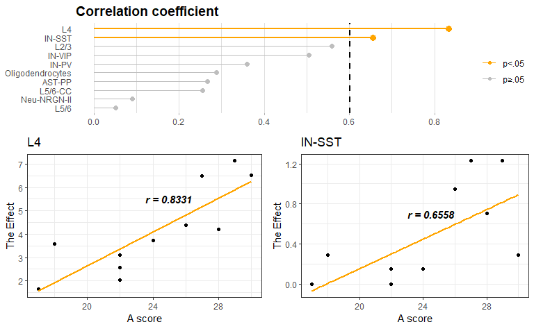

```r
p1 <- df %>% filter(A > 13 & `Cell type` == 'L4') %>%
  ggplot(aes(A, effect)) + geom_point() +
  geom_smooth(method = 'lm', se = F, col = "orange") + ggtitle('L4') +
  geom_text(data = data.frame(x = 25, y = 5.5, text = "r = 0.8331"),
            aes(x, y, label = text), size = 4, fontface = "bold.italic") +
  xlab("A score") + ylab("The Effect") + theme_bw()
p2 <- df %>% filter(A > 13 & `Cell type` == 'IN-SST') %>%
  ggplot(aes(A, effect)) + geom_point() +
  geom_smooth(method = 'lm', se = F, col = "orange") + ggtitle('IN-SST') +
  geom_text(data = data.frame(x = 24.5, y = 0.7, text = "r = 0.6558"),
            aes(x, y, label = text), size = 4, fontface = "bold.italic") +
  xlab("A score") + ylab("The Effect") + theme_bw()
p3 <- corr %>% mutate(`Cell type` = reorder(`Cell type`, r)) %>%
  ggplot(aes(col = ifelse(corr$`Cell type` %in% c("L4","AST-FB", "IN-SST"), "p<.05", "p≥.05"))) +
  geom_point(aes(r, `Cell type`),
             size = ifelse(corr$`Cell type` %in% c("L4","AST-FB", "IN-SST"),
                                      3, 2)) +
  geom_segment(aes(0, `Cell type`, xend = r, yend = `Cell type`),
               size = ifelse(corr$`Cell type` %in% c("L4","AST-FB", "IN-SST"), 1, 0.5)) +
  geom_vline(aes(xintercept = 0.6021), lty = 2, size = 1) +
  scale_color_manual(values = c("orange", "grey")) +
  theme_light() +
  theme(panel.grid.major.y = element_blank(),
    panel.border = element_blank(),
    axis.ticks.y = element_blank(),
    legend.title = element_blank(),
    title = element_text(face = "bold", size = 12)) +
  labs(title = "Correlation coefficient", x = NULL, y = NULL)
plot_grid(p3, plot_grid(p1, p2, nrow = 1), nrow = 2, rel_heights = c(1, 1.5))
```

## **4. Discussion**

이 분석에서의 한계은 각각의 Patient와 Control 간의 Fold change 정보를 이용할 수 없어서, 전체 환자들과 Control에 대한 Fold change를 이용했다는 점이다. 또한 A score 점수가 없거나 이질적인 환자들을 배제했다. Sample size가 작다는 것도 이 분석의 결정적인 한계이다.

하지만 이 분석을 통해 Excitatory neurons(**L4**) 뿐만 아니라 GABAergic interneurons(**IN-SST**)에서도 환자 5명 이상에서 공통으로 나타나는 DEGs를 고려했을 때 Excitatory neurons보다 작음에도 불구하고 Clinical severity(reciprocal social interaction의 이상)와 상관있을 수 있다는 결과를 얻었다. 이와 관련하여 IN-SST에서 발현되는 유전자에 대해서 더 알아보면 좋을 것 같다.